# High Performance Computing in R, without rewriting your code

David Mawdsley & Pen Richardson

6 November 2017

# Introduction

- Waiting for your R code to run is a pain
- We’re going to talk about ways to make it faster
  - Without editing your code
- Two approaches:
  - Faster R
  - HPC at UoM

# Optimising code

- Problem specific
- Profiling is a good starting point
  - [Built into R studio](https://rstudio.github.io/profvis/)

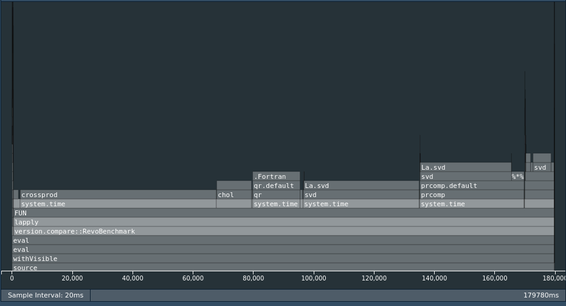

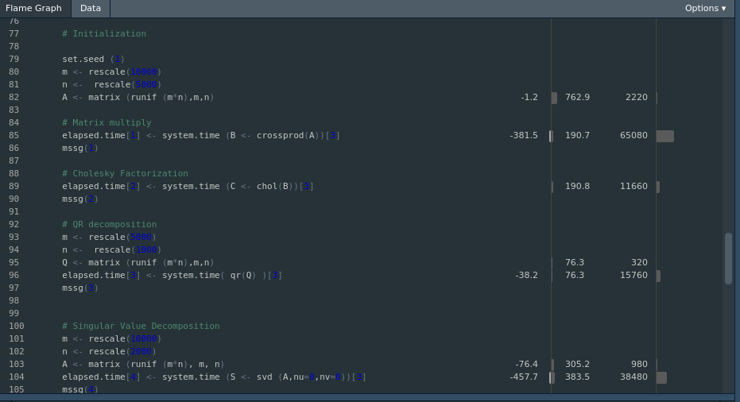

# Optimising *how* your code runs

- Most PCs have 2, 4 or 8 cores.
  - R will only use one of these by default
- Two approaches to using more of them:
  - Explicitly parallise code
    - Not covering this in this talk
  - *Use a version of R with libraries that use > 1 core*

# Microsoft R Open

- [MS R Open](https://mran.microsoft.com/open/) uses optimised versions of [BLAS and LAPACK](https://software.intel.com/en-us/mkl).
  - Typically quicker even on a single thread
  - (Usually) even quicker if we use multiple threads
- Speed up will depend on *what* you’re doing
  - Linear algebra

# Benchmarking R

Used the Revobenchmark in the version.compare package:

- Matrix multiplication
- Cholesky factorisation
- QR Decomposition
- Singular value decomposition
- PCA
- Linear Discriminant Analysis

(See [MS R Blog](https://mran.microsoft.com/documents/rro/multithread/) for more details)

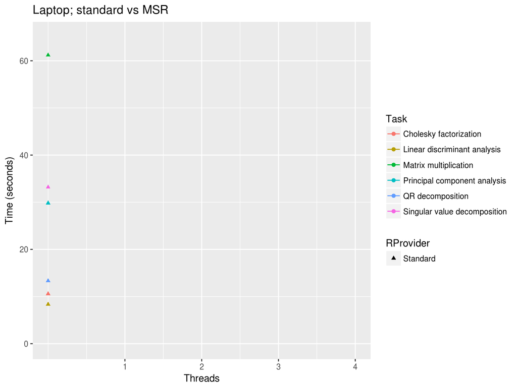

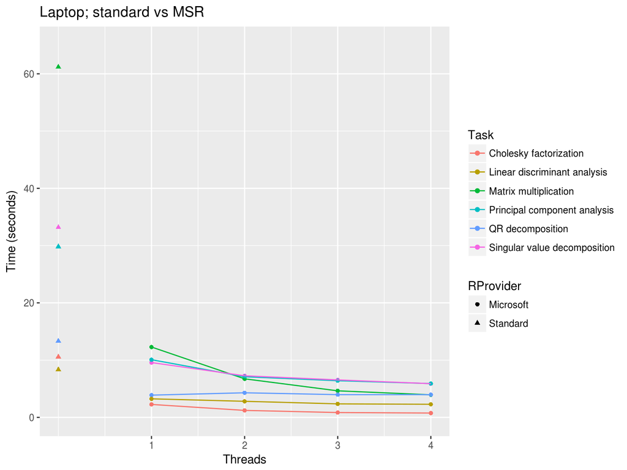

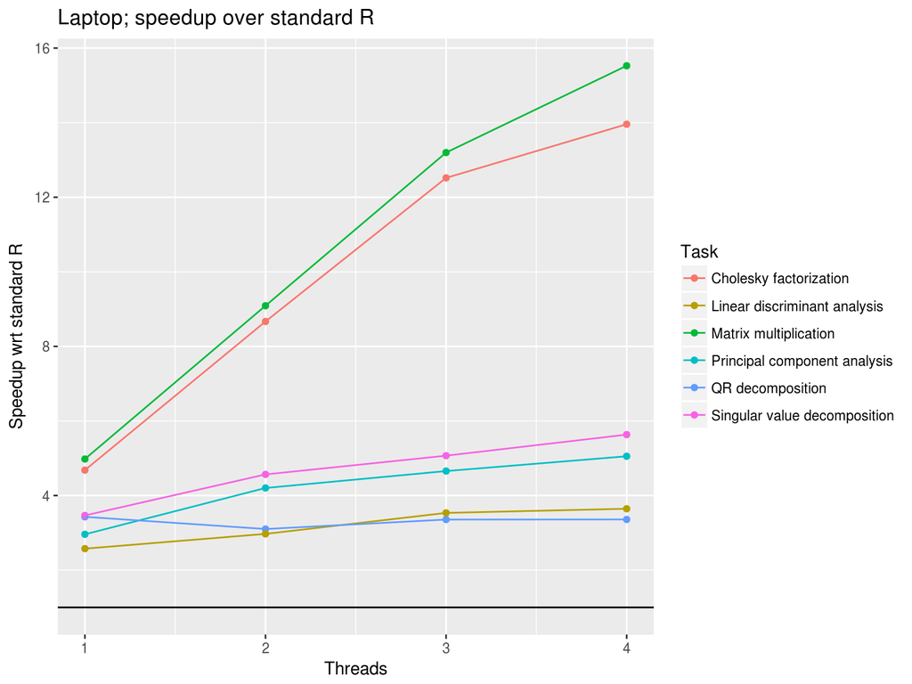

# Compatibility between standard R and Microsoft R open

- Version lags (slightly) behind standard R
- [“100% compatible with”](https://mran.microsoft.com/open/) standard R
- Uses its own version of [CRAN](https://cran.r-project.org/); MRAN
  - Frozen snapshot of CRAN for each release of MS R Open
  - Can install CRAN packages with `repos="URL"` option
  - `checkpoint` library lets you use packages at arbitrary snapshot dates

# What if this isn’t enough?

[figure not shown]

# The CSF

- [George Leaver talked about the iCSF in March](http://ri.itservices.manchester.ac.uk/course/herc/icsf.pdf)
  - Interactive facility
- We’ll focus on the [CSF](http://ri.itservices.manchester.ac.uk/csf/)
  - “Traditional” batch system
  - Write a job script, submit it, wait for it to run
- Aimed at research groups who have contributed to it
  - Limited free at the point of use availability
- Has [several versions of standard R and MS R Open](http://ri.itservices.manchester.ac.uk/csf-apps/software/applications/r/) installed.

# Getting started on the CSF

- [Applying for an account](http://ri.itservices.manchester.ac.uk/csf/getting-started-on-the-csf/user-account/)
- [Training course](http://www.staffnet.manchester.ac.uk/staff-learning-and-development/academicandresearch/practical-skills-and-knowledge/it-skills/research-computing/research-courses/)
- Demonstrations:
  1. [Running a job](http://ri.itservices.manchester.ac.uk/userdocs/sge/tutorial/) on multiple cores
  2. Running the same job many times ([job arrays](http://ri.itservices.manchester.ac.uk/userdocs/sge/job-arrays/))

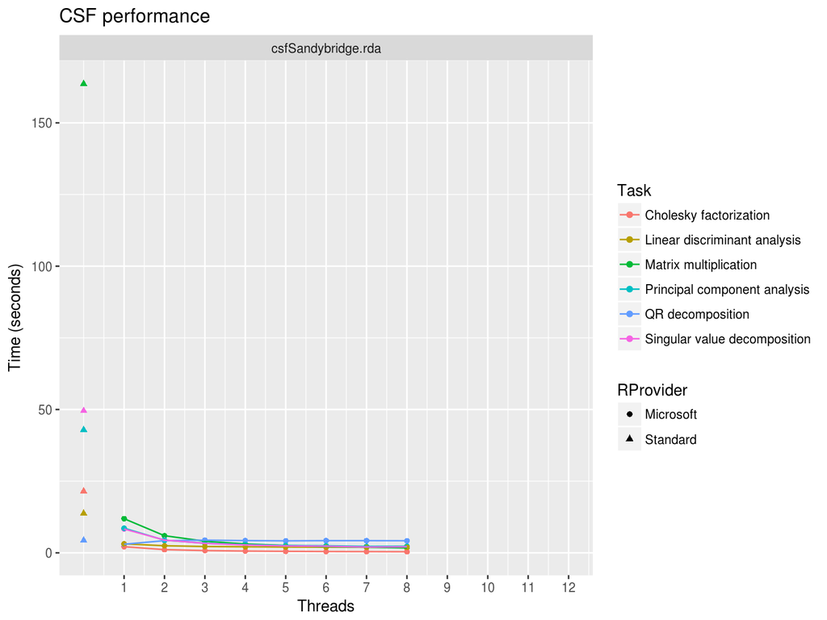

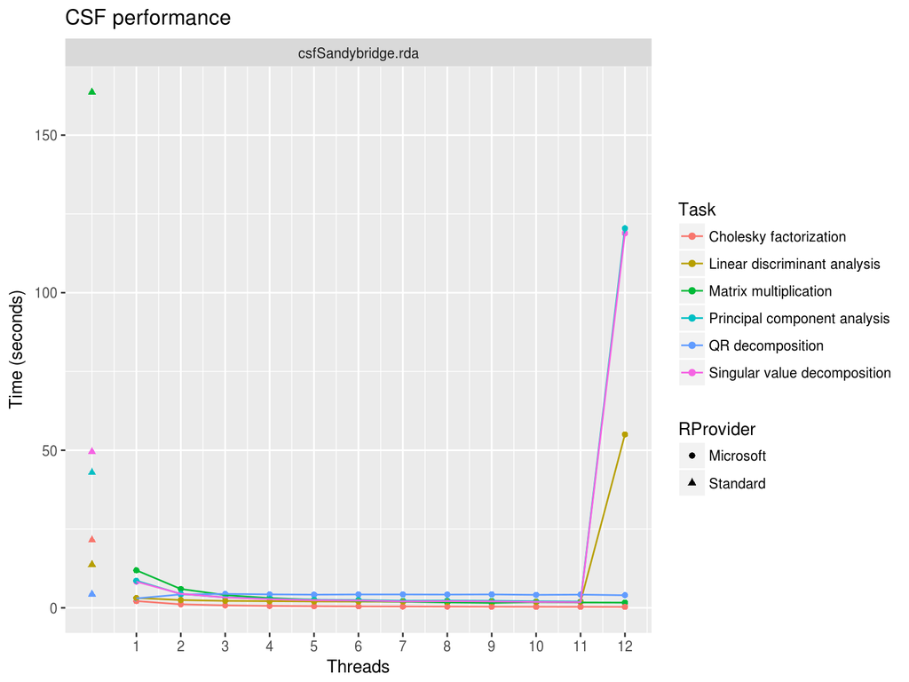

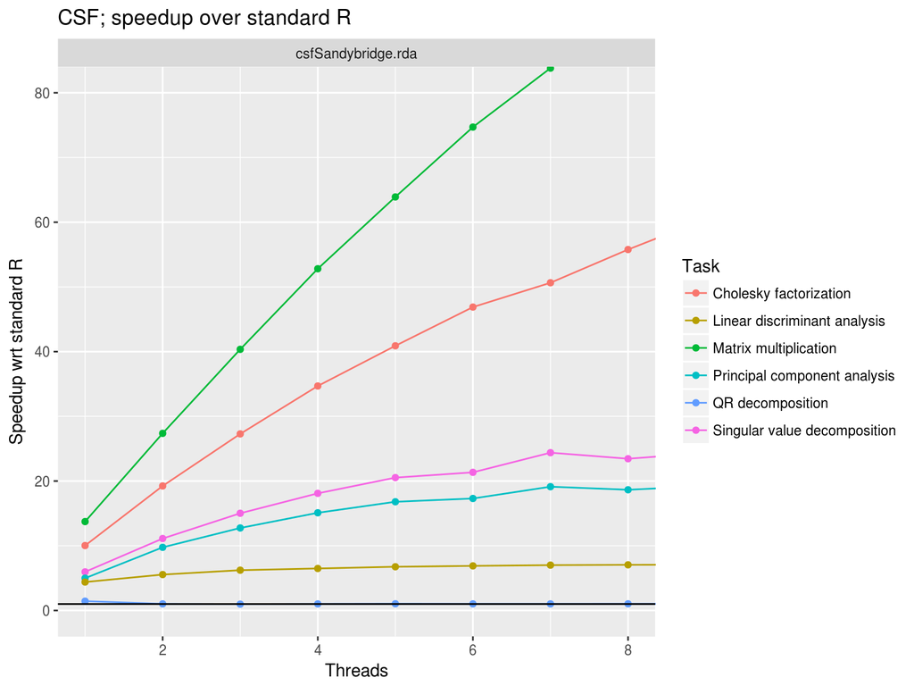

# Setting the number of threads

- Unclear why performance suffers if all cores used
  - Little benefit in > 8 cores
  - Less queuing time; easier to schedule jobs
- Set cores required with

  ```
  #$ -pe smp.pe 8
  ```

  in your job script
- You *must* include the line:

  ```
  export OMP_NUM_THREADS=$NSLOTS
  ```

  in your job submission script

# The parallel library and MS R Open

- Take care not to “double parallise”
  - Each processes spawned by `parallel` will spawn its own threads
  - can limit threads used by *each* process with

    ```
    setMKLthreads(<n>)
    ```

  - Experimentation will be needed to find the best balance between the two approaches

# Getting help/training

- [Research IT training courses](http://www.staffnet.manchester.ac.uk/staff-learning-and-development/academicandresearch/practical-skills-and-knowledge/it-skills/research-computing/research-courses/)
  - Next CSF course 20 November.
  - Next R courses 28 November and 5 December
  - Courses on Unix shell and Makefiles may also be of interest
- Feel free to get in touch directly, or via the [Research IT request form](http://www.itservices.manchester.ac.uk/research/support/)
  - david.mawdsley@manchester.ac.uk
  - pen.richardson@manchester.ac.uk
- These slides are availabile at https://mawds.github.io/RUGCSF/RUGCSF.html

# Conclusions

- Switching over to MS R Open can offer big speedups
  - No modification of code needed
  - Though some care needed with package versions
- The CSF is ideal for
  - bigger jobs
  - repeated jobs (using job arrays)
- Important to set the number of threads correctly